# SMARTPHONES

2022-06-07

## R Markdown

PUNUAN: Dallendyshe Islamaj Artiola Brazhda

#Importimi i databazes

```r
library(readxl)
smart <- read_excel("C:/Users/user/Desktop/projekti i statistikes/smart.xlsx")
View(smart)
```

#Afishimi i te dhenave per kompanine Apple

```r
head(smart,15)
```

| Company | Device | CPU | GPU | ROM | Cores | Cmimi | Shitjet | Viti i prodhimit | RAM |
| --- | --- | --- | --- | --- | --- | --- | --- | --- | --- |
| Apple | iPhone 13 Pro Max | Apple A15 Bionic | Apple GPU | 256 | 6 | 1200 | 20000000 | 2021 | 6 |
| Apple | iPhone 13 Pro | Apple A15 Bionic | Apple GPU | 256 | 6 | 1000 | 10000000 | 2021 | 6 |
| Apple | iPhone 13 mini | Apple A15 Bionic | Apple GPU | 256 | 6 | 800 | 7856320 | 2021 | 4 |
| Apple | iPad Pro 12 | Apple M1 | Apple GPU | 256 | 8 | 1250 | 5100259 | 2021 | 8 |
| Apple | Apple iPhone 12 | Apple A14 Bionic | Apple GPU | 256 | 4 | 600 | 95200450 | 2020 | 4 |
| Apple | Apple iPhone SE | Apple A13 Bionic | Apple GPU | 256 | 4 | 250 | 24000200 | 2016 | 3 |
| Apple | Apple iPhone 11 Pro Max | Apple A13 Bionic | Apple GPU | 256 | 4 | 550 | 10230654 | 2019 | 4 |
| Apple | Apple iPhone XS | Apple A12 Bionic | Apple GPU | 256 | 4 | 320 | 22500120 | 2018 | 4 |
| Apple | Apple iPhone XR | Apple A12 Bionic | Apple GPU | 256 | 4 | 250 | 8200100 | 2018 | 3 |
| Apple | Apple iPhone 4s | Apple A5 | PowerVR | 128 | 2 | 150 | 1750000 | 2011 | 8 |

[output cut: 5 more lines]

#Afishimi i te dhenave per kompanine Samsung

```r
smart[16:32,c(1,2,3,4,5,6,7,8,9,10)]
```

| Company | Device | CPU | GPU | ROM | Cores | Cmimi | Shitjet | Viti i prodhimit | RAM |
| --- | --- | --- | --- | --- | --- | --- | --- | --- | --- |
| Samsung | Samsung Galaxy S20 FE | Qualcomm | Adreno | 128 | 8 | 520 | 10000000 | 2022 | 6 |
| Samsung | Samsung Galaxy S22 Ultra 5G | Qualcomm | Adreno | 256 | 8 | 1300 | 2000500 | 2022 | 12 |
| Samsung | Samsung Galaxy Tab S8+ | Qualcomm | Adreno | 256 | 8 | 950 | 20500320 | 2022 | 8 |
| Samsung | Samsung Galaxy A03 | Unisoc | IMG | 32 | 8 | 110 | 3200000 | 2021 | 3 |
| Samsung | Samsung Galaxy A12 | Exynos | Mali | 128 | 8 | 150 | 51800000 | 2021 | 4 |
| Samsung | Samsung Galaxy F22 | Mediatek | Mali | 128 | 8 | 150 | 14200452 | 2021 | 6 |
| Samsung | Samsung Galaxy F02s | Qualcomm | Adreno | 64 | 4 | 100 | 6200410 | 2021 | 4 |
| Samsung | Samsung Galaxy A32 | Mediatek | Mali | 128 | 8 | 200 | 12150216 | 2021 | 6 |
| Samsung | Samsung Galaxy S21 Ultra 5G | Qualcomm | Mali | 256 | 8 | 1200 | 20150651 | 2021 | 12 |
| Samsung | Samsung Galaxy Note20 Ultra 5G | Exynos | Mali | 256 | 8 | 900 | 18600745 | 2020 | 8 |

[output cut: 7 more lines]

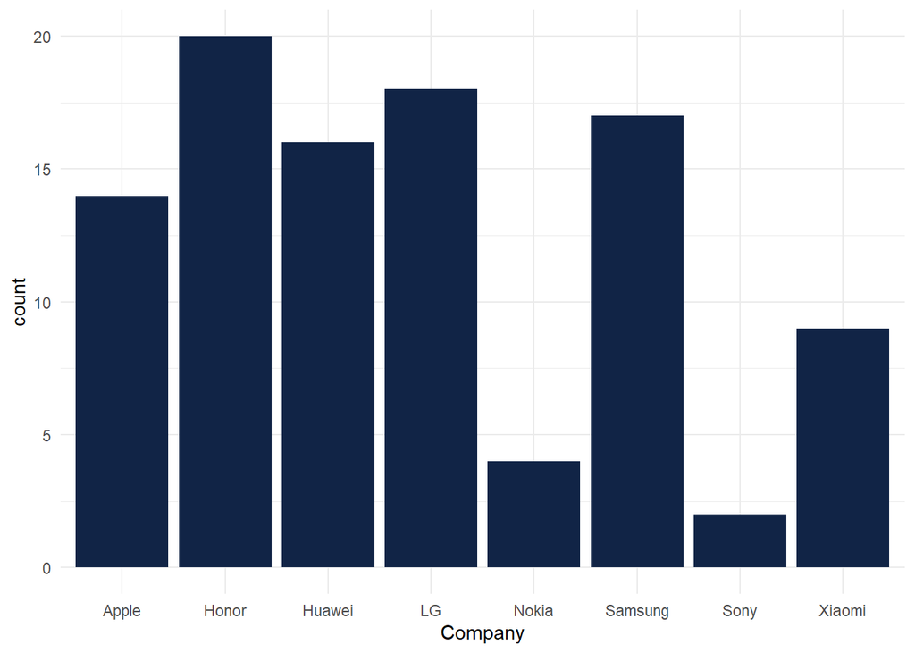

```r
library(ggplot2)
library(dplyr)
library(hrbrthemes)
smart %>%
 filter(!(GPU %in% c("PowerVR \r\n", "Mali\r\n", "Adreno \r\n", "IMG\r\n", "Adreno\r\n"))) %>%
 ggplot() +
  aes(x = Company) +
  geom_bar(fill = "#112446") +
  theme_minimal()
```

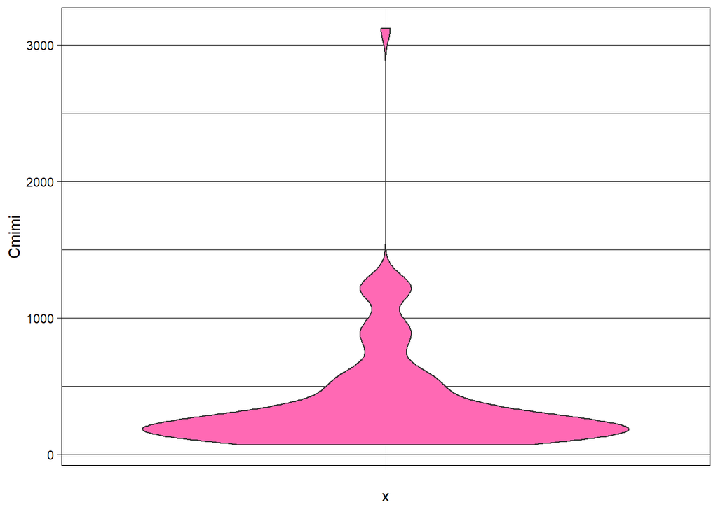

```r
#grafik per cmimet
smart %>%
 filter(!(GPU %in% c("PowerVR \r\n", "Mali\r\n", "Adreno \r\n", "IMG\r\n", "Adreno\r\n"))) %>%
 ggplot() +
  aes(x = "", y = Cmimi) +
  geom_violin(adjust = 1L, scale = "area", fill = "#FF69B4") +
  theme_linedraw()
```

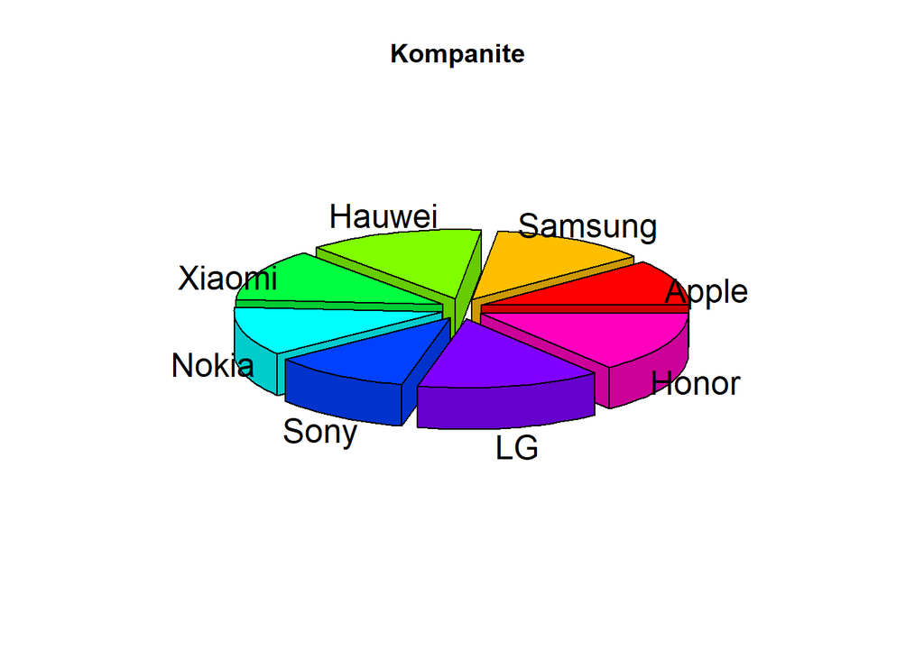

```r
library(plotrix)
slices <- c(15, 17, 19, 17, 16,15,20,20)
lbls <- c("Apple", "Samsung", "Hauwei", "Xiaomi", "Nokia","Sony","LG","Honor")
pie3D(slices,labels=lbls,explode=0.1,
   main="Kompanite ")
```

```r
#Afishimi per kompanine Huawei

smart [33:51,c(1,2,3,4,5,6,7,8,9,10)]
```

| Company | Device | CPU | GPU | ROM | Cores | Cmimi | Shitjet | Viti i prodhimit | RAM |
| --- | --- | --- | --- | --- | --- | --- | --- | --- | --- |
| Huawei | Huawei P50E | Qualcomm | Adreno | 256 | 8 | 600 | 6800625 | 2021 | 8 |
| Huawei | Huawei nova 9 SE 5G | Qualcomm | Adreno | 256 | 8 | 370 | 4961236 | 2022 | 8 |
| Huawei | Huawei nova 9 | Qualcomm | Adrene | 256 | 8 | 400 | 16520890 | 2021 | 8 |
| Huawei | Huawei P50 | Qualcomm | Adreno | 256 | 8 | 720 | 8200652 | 2021 | 8 |
| Huawei | Huawei Mate 40E 4G | Kirin | Mali | 256 | 8 | 600 | 10200561 | 2021 | 8 |
| Huawei | Huawei Mate X2 4G | Kirin | Mali | 256 | 8 | 3120 | 5500890 | 2021 | 8 |
| Huawei | Huawei nova 8 Pro 4G | Kirin | Mali | 256 | 8 | 550 | 15500900 | 2021 | 8 |
| Huawei | Huawei P40 lite | Kirin | Mali | 128 | 8 | 255 | 6900000 | 2020 | 6 |
| Huawei | Huawei P30 lite | Kirin | Mali | 256 | 8 | 400 | 12560500 | 2020 | 6 |
| Huawei | Huawei nova 6 | Kirin | Mali\r\n | 128 | 8 | 280 | 20200360 | 2019 | 8 |

[output cut: 9 more lines]

#Afishimi per kompanine Xiaomi

```r
smart[52:68,c(1,2,3,4,5,6,7,8,9,10)]
```

| Company | Device | CPU | GPU | ROM | Cores | Cmimi | Shitjet | Viti i prodhimit | RAM |
| --- | --- | --- | --- | --- | --- | --- | --- | --- | --- |
| Xiaomi | Xiaomi Redmi Note 11SE | MediaTek | Mali | 128 | 8 | 150 | 5600890 | 2022 | 8 |
| Xiaomi | Xiaomi Redmi 10 Prime | MediaTek | Mali\r\n | 128 | 8 | 148 | 8600620 | 2022 | 6 |
| Xiaomi | Xiaomi Civi 1S | Qualcomm | Adreno | 256 | 8 | 350 | 15600000 | 2022 | 12 |
| Xiaomi | Xiaomi Redmi 10 Power | Qualcomm | Adreno | 128 | 8 | 194 | 23900000 | 2022 | 8 |
| Xiaomi | Xiaomi Black Shark 5 RS | Qualcomm | Adreno | 256 | 8 | 500 | 1723900 | 2022 | 12 |
| Xiaomi | Xiaomi Redmi Note 11S 5G | MediaTek | Mali | 128 | 8 | 285 | 13500900 | 2022 | 6 |
| Xiaomi | Xiaomi Redmi Note 10T | MediaTek | Mali\r\n | 128 | 8 | 155 | 30750600 | 2021 | 6 |
| Xiaomi | Xiaomi Redmi Note 8 | MediaTek | Mali | 128 | 8 | 200 | 23900560 | 2021 | 4 |
| Xiaomi | Xiaomi Mi 11 Pro | Qualcomm | Adreno | 256 | 8 | 900 | 14654320 | 2021 | 12 |
| Xiaomi | Xiaomi Mi 9 Lite | Qualcomm | Adreno \r\n | 128 | 8 | 350 | 35810200 | 2019 | 12 |

[output cut: 7 more lines]

#Afishimi per kompanine Nokia

```r
smart[69:84,c(1,2,3,4,5,6,7,8,9,10)]
```

| Company | Device | CPU | GPU | ROM | Cores | Cmimi | Shitjet | Viti i prodhimit | RAM |
| --- | --- | --- | --- | --- | --- | --- | --- | --- | --- |
| Nokia | Nokia C21 Plus | Unisoc | IMG | 64 | 8 | 245 | 3500600 | 2022 | 4 |
| Nokia | Nokia C21 | Unisoc | IMG | 64 | 8 | 80 | 6900510 | 2022 | 3 |
| Nokia | Nokia G21 | Unisoc | Mali\r\n | 128 | 8 | 230 | 10300600 | 2022 | 6 |
| Nokia | Nokia G300 | Qualcomm | Adreno \r\n | 64 | 8 | 200 | 20600310 | 2021 | 4 |
| Nokia | Nokia G50 | Qualcomm | Adreno \r\n | 128 | 8 | 250 | 21561360 | 2021 | 6 |
| Nokia | Nokia C30 | Unisoc | IMG\r\n | 64 | 8 | 100 | 13256941 | 2021 | 3 |
| Nokia | Nokia C20 | Unisoc | IMG\r\n | 32 | 4 | 90 | 5589630 | 2021 | 2 |
| Nokia | Nokia C10 | Unisoc | Mali\r\n | 32 | 4 | 80 | 7651230 | 2021 | 2 |
| Nokia | Nokia G10 | MediaTek | PowerVR | 64 | 8 | 130 | 10265891 | 2021 | 4 |
| Nokia | Nokia 3.4 | Qualcomm | Adreno \r\n | 64 | 8 | 150 | 15561260 | 2020 | 4 |

[output cut: 6 more lines]

#Afishimi per kompanine Sony

```r
smart[85:99,c(1,2,3,4,5,6,7,8,9,10)]
```

| Company | Device | CPU | GPU | ROM | Cores | Cmimi | Shitjet | Viti i prodhimit | RAM |
| --- | --- | --- | --- | --- | --- | --- | --- | --- | --- |
| Sony | Sony Xperia 1 IV | Qualcomm | Adreno | 256 | 8 | 1200 | 5690156 | 2022 | 12 |
| Sony | Sony Xperia Pro-I | Qualcomm | Adreno\r\n | 512 | 8 | 1160 | 10256923 | 2021 | 12 |
| Sony | Sony Xperia 1 IV | Qualcomm | Adreno \r\n | 256 | 8 | 1090 | 13569569 | 2021 | 12 |
| Sony | Sony Xperia 1 III | Qualcomm | Adreno \r\n | 256 | 8 | 780 | 26531496 | 2021 | 12 |
| Sony | Sony Xperia 5 II | Qualcomm | Adreno \r\n | 256 | 8 | 500 | 13568961 | 2020 | 8 |
| Sony | Sony Xperia L4 | Mediatek | PowerVR \r\n | 64 | 8 | 220 | 17560569 | 2020 | 3 |
| Sony | Sony Xperia XZ1 | Qualcomm | Adreno \r\n | 64 | 8 | 280 | 21258169 | 2017 | 4 |
| Sony | Sony Xperia XA2 Plus | Qualcomm | Adreno \r\n | 64 | 8 | 240 | 16154891 | 2018 | 6 |
| Sony | Sony Xperia XA2 Ultra | Qualcomm | Adreno\r\n | 64 | 8 | 260 | 9264186 | 2018 | 4 |
| Sony | Sony Xperia L2 | Mediatek | Mali\r\n | 32 | 4 | 140 | 5259631 | 2018 | 3 |

[output cut: 5 more lines]

#Afishimi per kompanine LG

```r
smart[100:119,c(1,2,3,4,5,6,7,8,9,10)]
```

| Company | Device | CPU | GPU | ROM | Cores | Cmimi | Shitjet | Viti i prodhimit | RAM |
| --- | --- | --- | --- | --- | --- | --- | --- | --- | --- |
| LG | LG W41+ | MediaTek | PowerVR \r\n | 128 | 8 | 170 | 7891230 | 2021 | 4 |
| LG | LG W41 | MediaTek | PowerVR \r\n | 64 | 8 | 160 | 15621560 | 2021 | 4 |
| LG | LG W31+ | Mediatek | PowerVR | 128 | 8 | 120 | 13251496 | 2020 | 4 |
| LG | LG W11 | Mediatek | PowerVR | 32 | 8 | 110 | 6520169 | 2020 | 2 |
| LG | LG K92 5G | Qualcomm | Adreno | 128 | 8 | 320 | 9126148 | 2020 | 6 |
| LG | LG Q52 | Mediatek | PowerVR | 64 | 8 | 240 | 1620156 | 2020 | 4 |
| LG | LG K71 | Mediatek | PowerVR | 128 | 8 | 180 | 2150800 | 2020 | 4 |
| LG | LG K22 | Qualcomm | Adreno | 64 | 4 | 140 | 1300000 | 2020 | 3 |
| LG | LG W10 Alpha | Unisoc | IMG | 32 | 4 | 130 | 620253 | 2019 | 3 |
| LG | LG Velvet 5G | Qualcomm | Adreno | 128 | 8 | 470 | 984321 | 2020 | 8 |

[output cut: 10 more lines]

#Afishimi per kompanine Honor

```r
smart[120:139,c(1,2,3,4,5,6,7,8,9,10)]
```

| Company | Device | CPU | GPU | ROM | Cores | Cmimi | Shitjet | Viti i prodhimit | RAM |
| --- | --- | --- | --- | --- | --- | --- | --- | --- | --- |
| Honor | Honor Play 30 | Qualcomm | Adreno | 128 | 8 | 150 | 6541591 | 2022 | 8 |
| Honor | Honor Play6T Pro | MediaTek | Mali | 256 | 8 | 200 | 3250600 | 2022 | 8 |
| Honor | Honor Magic4 Lite | Qualcomm | Adreno | 128 | 8 | 430 | 2150600 | 2022 | 8 |
| Honor | Honor X9 | Qualcomm | Adreno | 128 | 8 | 230 | 4200980 | 2022 | 8 |
| Honor | Honor X8 | Qualcomm | Adreno | 128 | 8 | 240 | 3600900 | 2022 | 6 |
| Honor | Honor Magic4 | Qualcomm | Adreno | 256 | 8 | 900 | 10900541 | 2022 | 12 |
| Honor | Honor Magic V | Qualcomm | Adreno | 256 | 8 | 1200 | 7560500 | 2022 | 12 |
| Honor | Honor X30 | Qualcomm | Adreno | 256 | 8 | 210 | 26250800 | 2021 | 12 |
| Honor | Honor 60 Pro | Qualcomm | Adreno | 256 | 8 | 520 | 12500650 | 2021 | 8 |
| Honor | Honor X30 Max | MediaTek | Mali | 256 | 8 | 320 | 20500260 | 2021 | 8 |

[output cut: 10 more lines]

```r
#afishimi i llojeve te telefonave
smart$Device
```

```
##   [1] "iPhone 13 Pro Max"              "iPhone 13 Pro"
##   [3] "iPhone 13 mini"                 "iPad Pro 12"
##   [5] "Apple iPhone 12"                "Apple iPhone SE"
##   [7] "Apple iPhone 11 Pro Max"        "Apple iPhone XS"
##   [9] "Apple iPhone XR"                "Apple iPhone 4s"
##  [11] "Apple iPhone 3G"                "Apple iPhone 8"
##  [13] "Apple iPhone 7"                 "Apple iPhone 6s Plus"
##  [15] "Apple iPad mini 4"              "Samsung Galaxy S20 FE"
##  [17] "Samsung Galaxy S22 Ultra 5G"    "Samsung Galaxy Tab S8+"
##  [19] "Samsung Galaxy A03"             "Samsung Galaxy A12"
##  [21] "Samsung Galaxy F22"             "Samsung Galaxy F02s"
##  [23] "Samsung Galaxy A32"             "Samsung Galaxy S21 Ultra 5G"
##  [25] "Samsung Galaxy Note20 Ultra 5G" "Samsung Galaxy S7"
##  [27] "Samsung Galaxy A3"              "Samsung Galaxy V Plus"
##  [29] "Samsung Galaxy J5"              "Samsung Galaxy E5"
```

[output cut: 55 more lines]

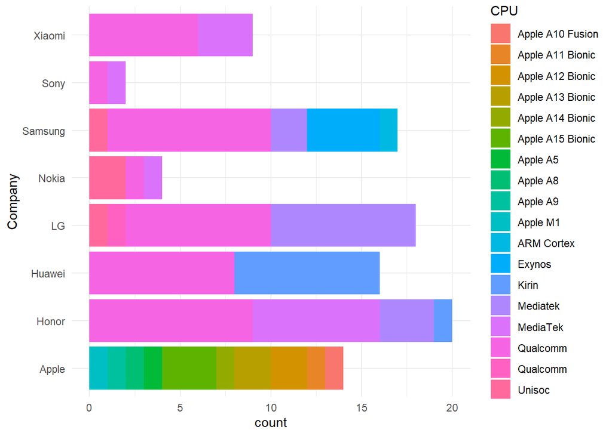

```r
library(ggplot2)
library(dplyr)
library(hrbrthemes)
#grafiku qe tregon lidhjen mes kompanive dhe cpu
smart %>%
 filter(!(GPU %in% c("PowerVR \r\n", "Mali\r\n", "Adreno \r\n", "IMG\r\n", "Adreno\r\n"
))) %>%
 ggplot() +
 aes(x = `Company`, fill = CPU) +
 geom_bar() +
 scale_fill_hue(direction = 1) +
 coord_flip() +
 theme_minimal()
```

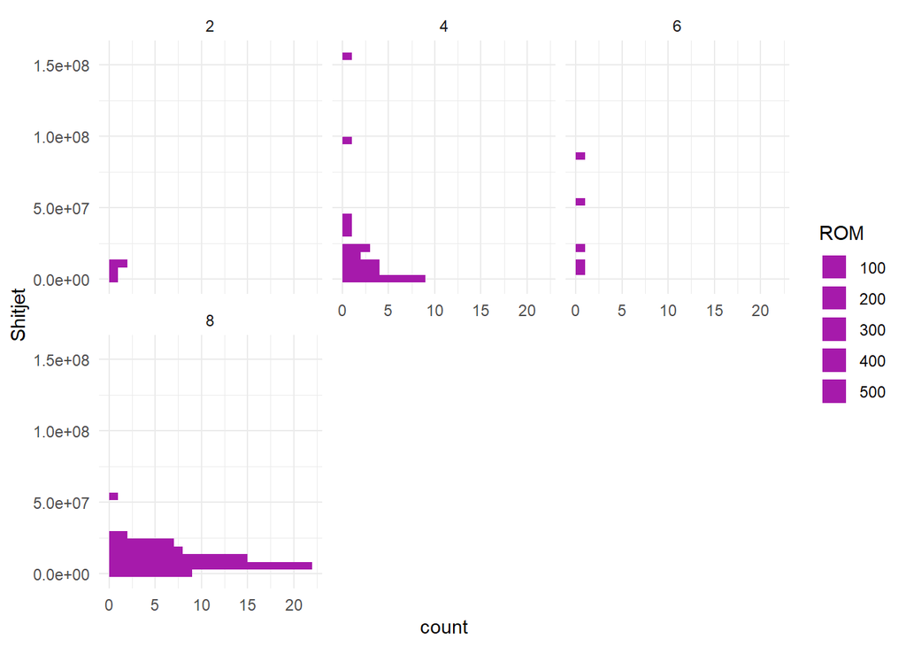

```r
#grafiku qe tregon lidhjen mes ROM dhe shitjeve
smart %>%
 filter(!(GPU %in% c("PowerVR \r\n", "Mali\r\n", "Adreno \r\n", "IMG\r\n", "Adreno\r\n"
))) %>%
 ggplot() +
 aes(x = Shitjet, size = ROM, group = RAM) +
 geom_histogram(bins = 30L, fill = "#A61AAB") +
 coord_flip() +
 theme_minimal() +
 facet_wrap(vars(Cores), ncol = 3L)
```

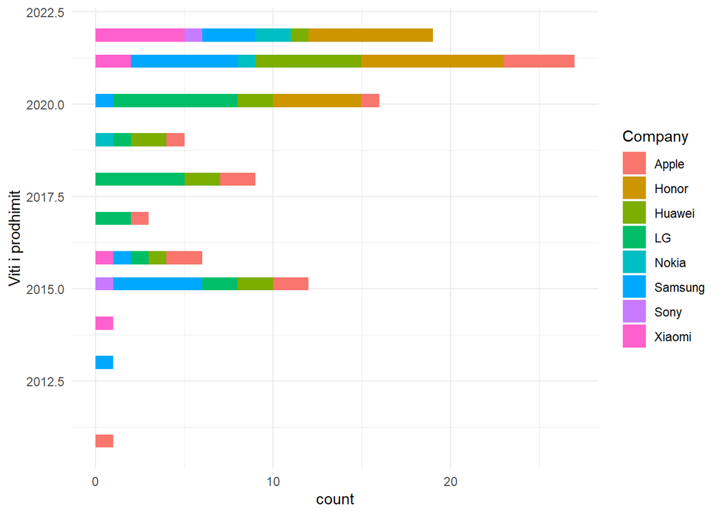

```r
library(ggplot2)
library(dplyr)
library(hrbrthemes)
smart %>%
 filter(!(GPU %in% c("PowerVR \r\n", "Mali\r\n", "Adreno \r\n", "IMG\r\n", "Adreno\r\n"
))) %>%
 ggplot() +
 aes(x = `Viti i prodhimit`, fill = `Company`) +
 geom_histogram(bins = 32L) +
 scale_fill_hue(direction = 1) +
 coord_flip() +
 theme_minimal()
```

#mesatarja e ROM

```r
mean(smart$ROM)
```

```
## [1] 136
```

#mesatarja per cores

```r
mean(smart$Cores)
```

```
## [1] 6.582734
```

#mesatarja per cmimin

```r
mean(smart$Cmimi)
```

```
## [1] 362.8058
```

#mesatarja per shitjet

```r
mean(smart$Shitjet)
```

```
## [1] 14201395
```

#mesatarja per RAM

```r
mean(smart$RAM)
```

```
## [1] 5.446043
```

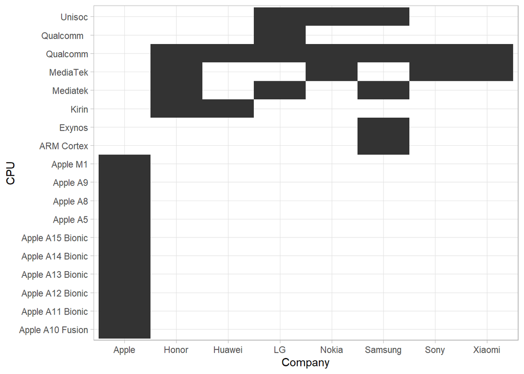

```r
#grafik qe tregon cfare cpu kane perdorur kompanite
smart %>%
 filter(!(GPU %in% c("PowerVR \r\n", "Mali\r\n", "Adreno \r\n", "IMG\r\n", "Adreno\r\n"))) %>%
 ggplot() +
  aes(x = Company, y = CPU) +
  geom_tile(size = 1.5) +
  theme_light()
```

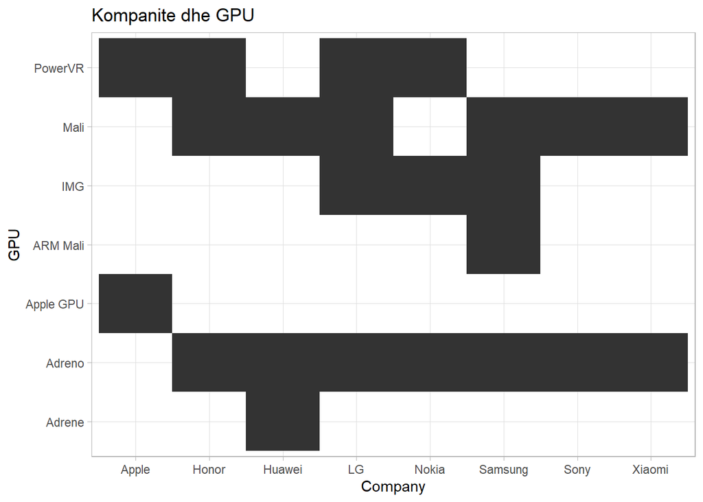

```r
#gpu dhe kompanite
smart %>%
 filter(!(GPU %in% c("PowerVR \r\n", "Mali\r\n", "Adreno \r\n", "IMG\r\n", "Adreno\r\n"))) %>%
 ggplot() +
  aes(x = Company, y = GPU) +
  geom_tile(size = 1.5) +
  labs(title = "Kompanite dhe GPU") +
  theme_light()
```

#mesorja per ROM

```r
median(smart$ROM)
```

```
## [1] 128
```

#mesorja per Cores

```r
median(smart$Cores)
```

```
## [1] 8
```

#mesorja per cmimin

```r
median(smart$Cmimi)
```

```
## [1] 230
```

#mesorja per shitjet

```r
median(smart$Shitjet)
```

```
## [1] 1e+07
```

#mesorja e RAM

```r
median(smart$RAM)
```

```
## [1] 4
```

```r
#funksioni per te llogaritur moden ne ndryshore cilesore
find_mode <- function(x) {
  u <- unique(x)
  tab <- tabulate(match(x, u))
  u[tab == max(tab)]
}

#moda per kompanite
data <- c(smart$Company)
# gjej mode
find_mode(data)
```

```
## [1] "LG"    "Honor"
```

```r
#funksioni per moden
find_mode <- function(x) {
  u <- unique(x)
  tab <- tabulate(match(x, u))
  u[tab == max(tab)]
}

#moda per llojin e telefonit
data <- c(smart$Device)

find_mode(data)
```

```
## [1] "Sony Xperia 1 IV"
```

```r
#funksioni per moden
find_mode <- function(x) {
  u <- unique(x)
  tab <- tabulate(match(x, u))
  u[tab == max(tab)]
}

#Moda per CPU
data <- c(smart$CPU)
#find mode
find_mode(data)
```

```
## [1] "Qualcomm"
```

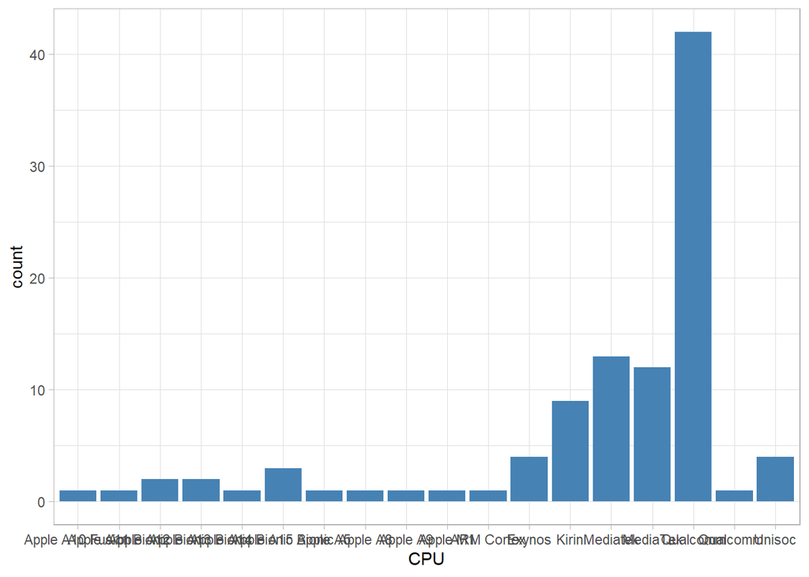

```r
#funksioni
find_mode <- function(x) {
  u <- unique(x)
  tab <- tabulate(match(x, u))
  u[tab == max(tab)]
}

smart %>%
 filter(!(GPU %in% c("PowerVR \r\n", "Mali\r\n", "Adreno \r\n", "IMG\r\n", "Adreno\r\n"))) %>%
 ggplot() +
  aes(x = CPU) +
  geom_bar(fill = "#4682B4") +
  theme_light()
```

```r
#moda per GPU
data <- c(smart$GPU)
#find mode
find_mode(data)
```

```
## [1] "Adreno"
```

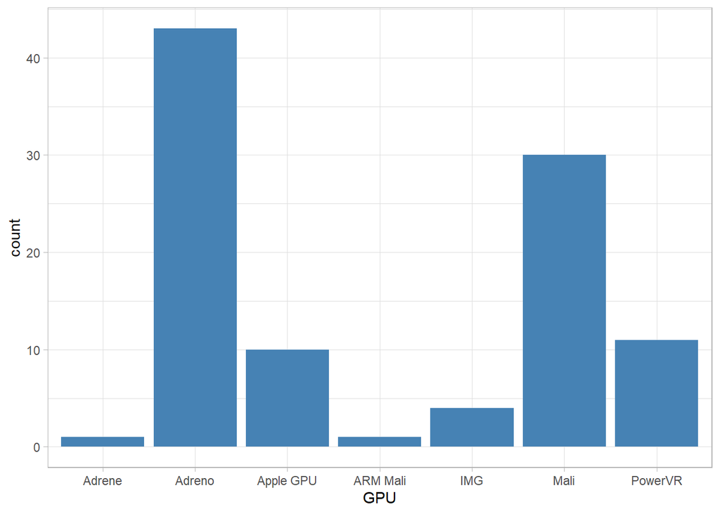

```r
#funksioni per te llogaritur moden
find_mode <- function(x) {
  u <- unique(x)
  tab <- tabulate(match(x, u))
  u[tab == max(tab)]
}

smart %>%
 filter(!(GPU %in% c("PowerVR \r\n", "Mali\r\n", "Adreno \r\n", "IMG\r\n", "Adreno\r\n"))) %>%
 ggplot() +
  aes(x = GPU) +
  geom_bar(fill = "#4682B4") +
  theme_light()
```

```r
#moda per ROM
data <- c(smart$ROM)

#find mode
find_mode(data)
```

```
## [1] 128
```

#funksioni per te llogaritur moden

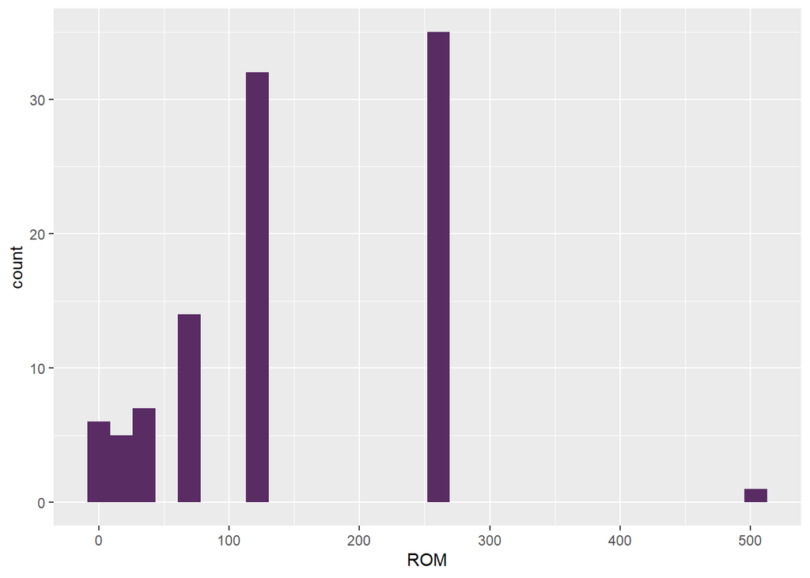

```r
  find_mode <- function(x) {
  u <- unique(x)
  tab <- tabulate(match(x, u))
  u[tab == max(tab)]
}

smart %>%
 filter(!(GPU %in% c("PowerVR \r\n", "Mali\r\n", "Adreno \r\n", "IMG\r\n", "Adreno\r\n"))) %>%
 ggplot() +
  aes(x = ROM) +
  geom_histogram(bins = 30L, fill = "#592C64") +
  theme_gray()
```

```r
#moda per SCORES
data <- c(smart$Cores)

#find mode
find_mode(data)
```

```
## [1] 8
```

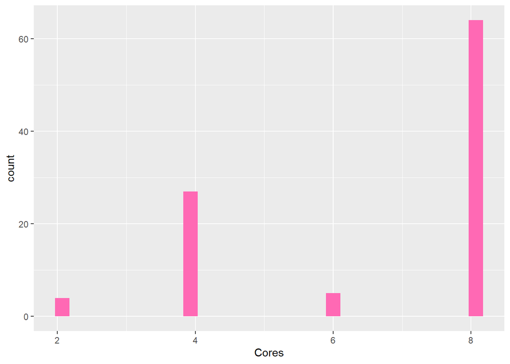

```r
# function to calculate mode
find_mode <- function(x) {
  u <- unique(x)
  tab <- tabulate(match(x, u))
  u[tab == max(tab)]
}
smart %>%
 filter(!(GPU %in% c("PowerVR \r\n", "Mali\r\n", "Adreno \r\n", "IMG\r\n", "Adreno\r\n"))) %>%
 ggplot() +
  aes(x = Cores) +
  geom_histogram(bins = 30L, fill = "#FF69B4") +
  theme_gray()
```

```r
#moda per Cmimin
data <- c(smart$Cmimi)

#find mode
find_mode(data)
```

```
## [1] 200
```

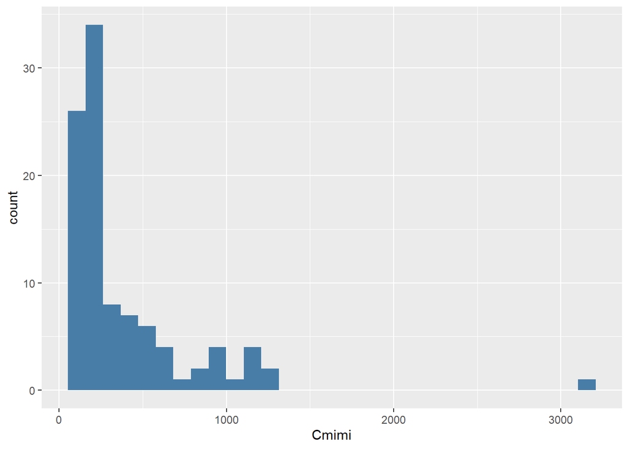

```r
#function to calculate mode
find_mode <- function(x) {
  u <- unique(x)
  tab <- tabulate(match(x, u))
  u[tab == max(tab)]
}
smart %>%
 filter(!(GPU %in% c("PowerVR \r\n", "Mali\r\n", "Adreno \r\n", "IMG\r\n", "Adreno\r\n"))) %>%
 ggplot() +
  aes(x = Cmimi) +
  geom_histogram(bins = 30L, fill = "#487DA8") +
  theme_gray()
```

```r
#moda per Shitjet
data <- c(smart$Shitjet)

#find mode
find_mode(data)
```

```
## [1] 10000000 13500900
```

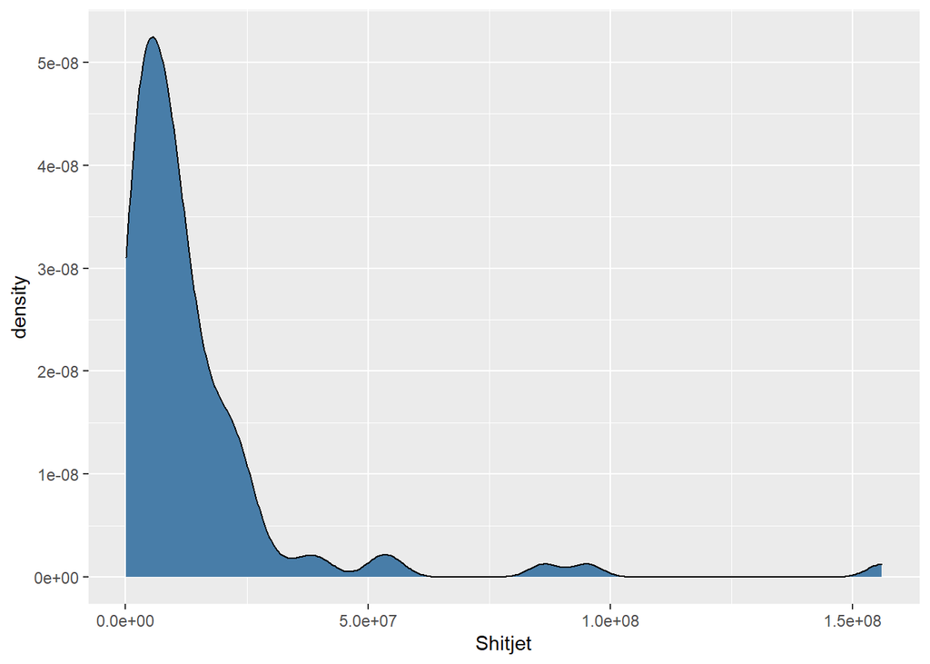

```r
#function to calculate mode
find_mode <- function(x) {
  u <- unique(x)
  tab <- tabulate(match(x, u))
  u[tab == max(tab)]
}

smart %>%
 filter(!(GPU %in% c("PowerVR \r\n", "Mali\r\n", "Adreno \r\n", "IMG\r\n", "Adreno\r\n"))) %>%
 ggplot() +
  aes(x = Shitjet) +
  geom_density(adjust = 1L, fill = "#487DA8") +
  theme_gray()
```

```r
#moda per Vitin
data <- c(smart$`Viti i prodhimit`)

#find mode
find_mode(data)
```

```
## [1] 2021
```

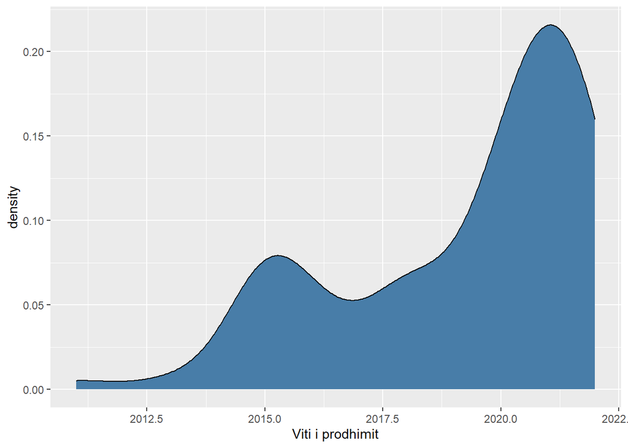

```r
#function to calculate mode
find_mode <- function(x) {
  u <- unique(x)
  tab <- tabulate(match(x, u))
  u[tab == max(tab)]
}

smart %>%
 filter(!(GPU %in% c("PowerVR \r\n", "Mali\r\n", "Adreno \r\n", "IMG\r\n", "Adreno\r\n"))) %>%
 ggplot() +
  aes(x = `Viti i prodhimit`) +
  geom_density(adjust = 1L, fill = "#487DA8") +
  theme_gray()
```

```r
#define numeric vector with multiple modes
data <- c(smart$RAM)

#find mode
find_mode(data)
```

```
## [1] 8
```

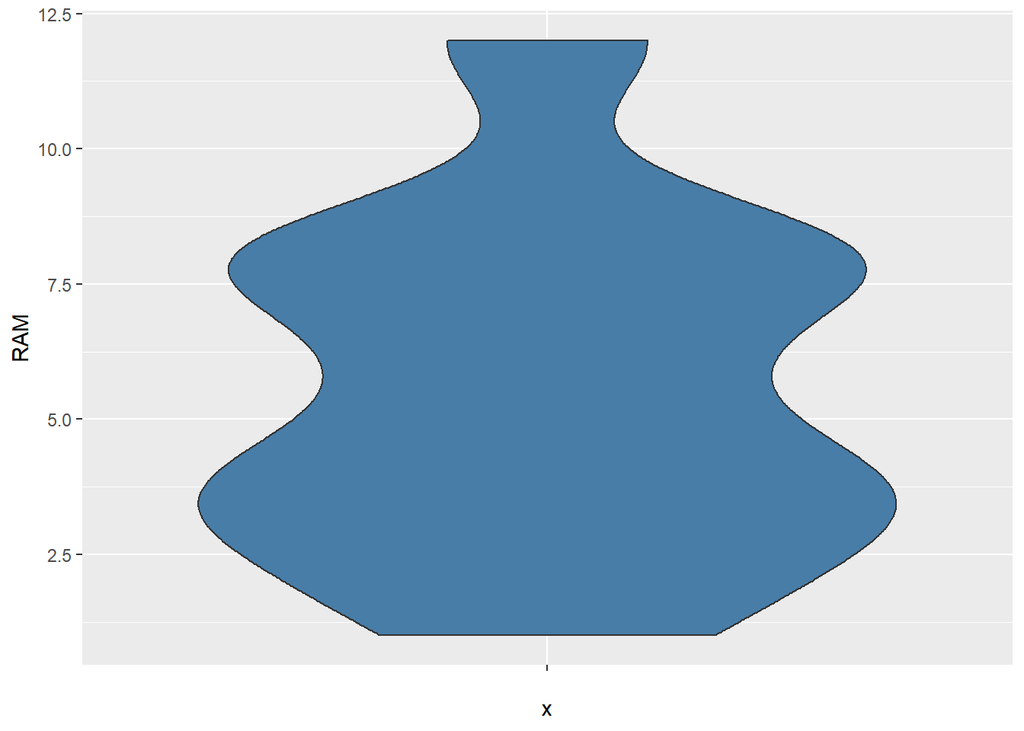

```r
find_mode <- function(x) {
 u <- unique(x)
  tab <- tabulate(match(x, u))
  u[tab == max(tab)]
}

  smart %>%
 filter(!(GPU %in% c("PowerVR \r\n", "Mali\r\n", "Adreno \r\n", "IMG\r\n", "Adreno\r\n"))) %>%
 ggplot() +
  aes(x = "", y = RAM) +
  geom_violin(adjust = 1L, scale = "area", fill = "#487DA8") +
  theme_gray()
```

#vlera minimale per ROM

```r
min(smart$ROM)
```

```
## [1] 8
```

#vlera minimale per Cores

```r
min(smart$Cores)
```

```
## [1] 1
```

#vlera minimale per cmimin

```r
min(smart$Cmimi)
```

```
## [1] 70
```

#vlera minimale per shitjet

```r
min(smart$Shitjet)
```

```
## [1] 105624
```

#vlera minimale per RAM

```r
min(smart$RAM)
```

```
## [1] 1
```

#vlera max per ROM

```r
max(smart$ROM)
```

```
## [1] 512
```

#vlera max per cores

```r
max(smart$Cores)
```

```
## [1] 8
```

#vlera max cmimi

```r
max(smart$Cmimi)
```

```
## [1] 3120
```

#vlera max per numrin e shitjeve

```r
max(smart$Shitjet)
```

```
## [1] 1.56e+08
```

#vlera max per RAM

```r
max(smart$RAM)
```

```
## [1] 12
```

#kuantilet per ROM

```r
quantile(smart$ROM)
```

```
##   0%  25%  50%  75% 100%
##    8   64  128  256  512
```

#kuantilet per Cores

```r
quantile(smart$Cores)
```

```
##   0%  25%  50%  75% 100%
##    1    4    8    8    8
```

#kuantilet per Cmimin

```r
quantile(smart$Cmimi)
```

```
##   0%  25%  50%  75% 100%
##   70  150  230  385 3120
```

#kuantilet per Numrin e shitjeve

```r
quantile(smart$Shitjet)
```

```
##        0%       25%       50%       75%      100%
##    105624   5545260  10000000  16500305 156000000
```

#kuantilet per RAM

```r
quantile(smart$RAM)
```

```
##   0%  25%  50%  75% 100%
##    1    3    4    8   12
```

#permbledhje per te dhenat

```r
summary(smart)
```

```
##    Company             Device              CPU                GPU
##  Length:139         Length:139         Length:139         Length:139
##  Class :character   Class :character   Class :character   Class :character
##  Mode  :character   Mode  :character   Mode  :character   Mode  :character
##
##
##
##       ROM          Cores           Cmimi           Shitjet
##  Min.   :  8   Min.   :1.000   Min.   :  70.0   Min.   :   105624
##  1st Qu.: 64   1st Qu.:4.000   1st Qu.: 150.0   1st Qu.:  5545260
##  Median :128   Median :8.000   Median : 230.0   Median : 10000000
##  Mean   :136   Mean   :6.583   Mean   : 362.8   Mean   : 14201395
##  3rd Qu.:256   3rd Qu.:8.000   3rd Qu.: 385.0   3rd Qu.: 16500305
##  Max.   :512   Max.   :8.000   Max.   :3120.0   Max.   :156000000
##  Viti i prodhimit      RAM
##  Min.   :2008     Min.   : 1.000
##  1st Qu.:2018     1st Qu.: 3.000
##  Median :2020     Median : 4.000
##  Mean   :2019     Mean   : 5.446
##  3rd Qu.:2021     3rd Qu.: 8.000
##  Max.   :2022     Max.   :12.000
```

#varianca e ROM

```r
var(smart$ROM)
```

```
## [1] 10022.96
```

#varianca e cores

```r
var(smart$Cores)
```

```
## [1] 4.042019
```

#varianca per cmimin

```r
var(smart$Cmimi)
```

```
## [1] 152318.9
```

#varianca per shitjet

```r
var(smart$Shitjet)
```

```
## [1] 3.326072e+14
```

#varianca per RAM

```r
var(smart$RAM)
```

```
## [1] 9.930039
```

#menjanimi mesatar katror per ROM

```r
sd(smart$ROM)
```

```
## [1] 100.1147
```

#menjanimi mesatar katror per cORE

```r
sd(smart$Cores)
```

```
## [1] 2.010477
```

#menjanimi mesatar katror per cmimin

```r
sd(smart$Cmimi)
```

```
## [1] 390.2806
```

```r
sd(smart$RAM)
```

```
## [1] 3.151196
```

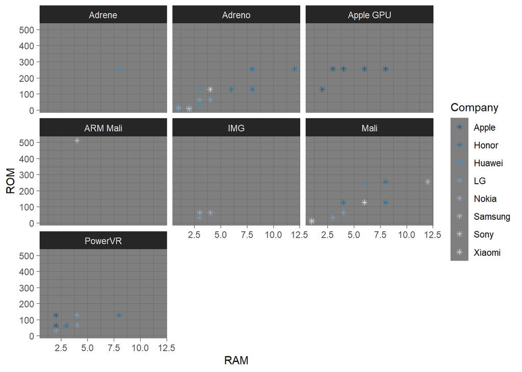

```r
#ram,rom,kompani,gpu
smart %>%
 filter(!(GPU %in% c("PowerVR \r\n", "Mali\r\n", "Adreno \r\n", "IMG\r\n", "Adreno\r\n"))) %>%
 ggplot() +
  aes(x = RAM, y = ROM, colour = Company) +
  geom_point(shape = "asterisk", size = 1.5) +
  scale_color_brewer(palette = "PuBu", direction = -1) +
  theme_dark() +
  facet_wrap(vars(GPU))
```

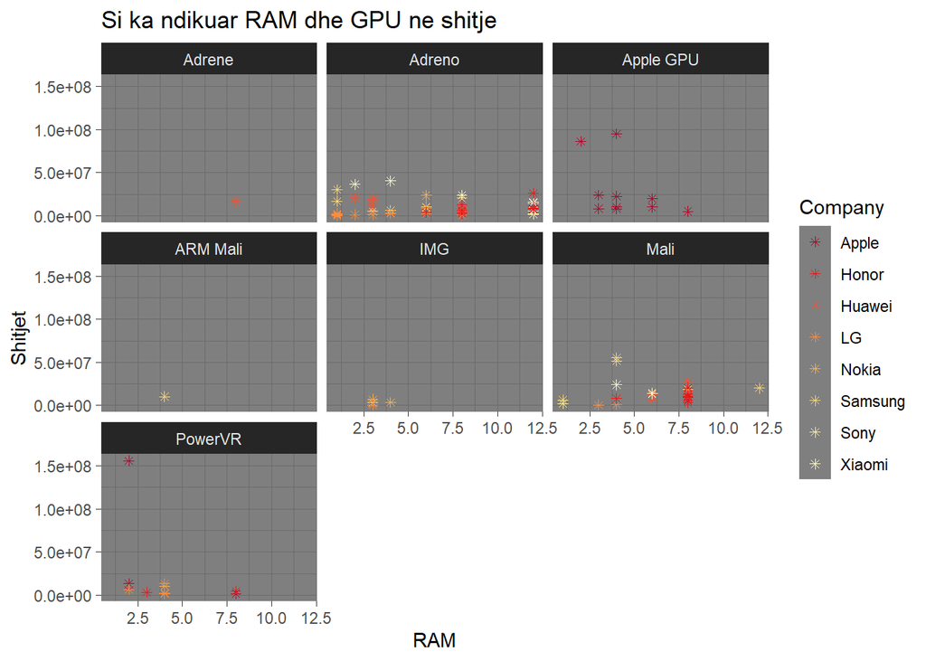

```r
smart %>%
 filter(!(GPU %in% c("PowerVR \r\n", "Mali\r\n", "Adreno \r\n", "IMG\r\n", "Adreno\r\n"))) %>%
 ggplot() +
  aes(x = RAM, y = Shitjet, colour = Company) +
  geom_point(shape = "asterisk", size = 1.5) +
  scale_color_brewer(palette = "YlOrRd", direction = -1) +
  labs(title = "Si ka ndikuar RAM dhe GPU ne shitje") +
  theme_dark() +
  facet_wrap(vars(GPU))
```

#tabela e kontigjences per kompanine dhe CPU dhe testi hi-katror

```r
table(smart$Company, smart$CPU)
```

```
##
##           Apple A10 Fusion Apple A11 Bionic Apple A12 Bionic Apple A13 Bionic
##   Apple                  1                1                2                2
##   Honor                  0                0                0                0
##   Huawei                 0                0                0                0
##   LG                     0                0                0                0
##   Nokia                  0                0                0                0
##   Samsung                0                0                0                0
##   Sony                   0                0                0                0
##   Xiaomi                 0                0                0                0
##
##           Apple A14 Bionic Apple A15 Bionic Apple A5 Apple A8 Apple A9 Apple M1
##   Apple                  1                3        1        1        1        1
##   Honor                  0                0        0        0        0        0
##   Huawei                 0                0        0        0        0        0
##   LG                     0                0        0        0        0        0
##   Nokia                  0                0        0        0        0        0
##   Samsung                0                0        0        0        0        0
##   Sony                   0                0        0        0        0        0
##   Xiaomi                 0                0        0        0        0        0
##
##           ARM 11 ARM Cortex Exynos Kirin Leadcore Mediatek MediaTek Qualcomm
##   Apple        1          0      0     0        0        0        0        0
##   Honor        0          0      0     1        0        3        7        9
##   Huawei       0          0      0    11        0        0        0        8
##   LG           0          0      0     0        0        8        2        8
##   Nokia        0          0      0     0        0        4        1        5
##   Samsung      0          1      4     0        0        2        0        9
##   Sony         0          0      0     0        0        3        1       11
##   Xiaomi       0          0      0     0        1        1        5        9
##
##           Qualcomm   Unisoc
##   Apple            0      0
##   Honor            0      0
##   Huawei           0      0
##   LG               1      1
##   Nokia            0      6
##   Samsung          0      1
##   Sony             0      0
##   Xiaomi           1      0
```

```r
library("MASS")
# krijojme dataframin nga dataseti i madh
smart.data <- data.frame(smart$CPU,smart$Company)

#krijojme tabelen
smart.data = table(smart$CPU,smart$Company)
print(smart.data)
```

```
##
##                    Apple Honor Huawei LG Nokia Samsung Sony Xiaomi
##   Apple A10 Fusion     1     0      0  0     0       0    0      0
##   Apple A11 Bionic     1     0      0  0     0       0    0      0
##   Apple A12 Bionic     2     0      0  0     0       0    0      0
##   Apple A13 Bionic     2     0      0  0     0       0    0      0
##   Apple A14 Bionic     1     0      0  0     0       0    0      0
##   Apple A15 Bionic     3     0      0  0     0       0    0      0
##   Apple A5             1     0      0  0     0       0    0      0
##   Apple A8             1     0      0  0     0       0    0      0
##   Apple A9             1     0      0  0     0       0    0      0
##   Apple M1             1     0      0  0     0       0    0      0
##   ARM 11               1     0      0  0     0       0    0      0
##   ARM Cortex           0     0      0  0     0       1    0      0
##   Exynos               0     0      0  0     0       4    0      0
##   Kirin                0     1     11  0     0       0    0      0
##   Leadcore             0     0      0  0     0       0    0      1
##   Mediatek             0     3      0  8     4       2    3      1
##   MediaTek             0     7      0  2     1       0    1      5
##   Qualcomm             0     9      8  8     5       9   11      9
##   Qualcomm             0     0      0  1     0       0    0      1
##   Unisoc               0     0      0  1     6       1    0      0
```

```r
# funksioni per hi-katrorin
print(chisq.test(smart.data))
```

```
##
##  Pearson's Chi-squared test
##
## data:  smart.data
## X-squared = 315.72, df = 133, p-value < 2.2e-16
```

#tabela e kontigjences dhe testi hi katror qe tregon nese dy ndryshore cilesore GPU dhe kompanine

```r
table(smart$Company, smart$GPU)
```

```
##
##           Adrene Adreno Adreno \r\n Adreno\r\n Apple GPU ARM Mali IMG IMG\r\n
##   Apple        0      0           0          0        10        0   0       0
##   Honor        0      9           0          0         0        0   0       0
##   Huawei       1      7           0          0         0        0   0       0
##   LG           0     11           0          0         0        0   1       0
##   Nokia        0      1           4          0         0        0   2       2
##   Samsung      0      8           0          0         0        1   1       0
##   Sony         0      1           7          3         0        0   0       0
##   Xiaomi       0      6           4          0         0        0   0       0
##
##           Mali Mali\r\n PowerVR PowerVR \r\n
##   Apple      0        0       4            1
##   Honor      9        0       2            0
##   Huawei     8        3       0            0
##   LG         2        0       4            2
##   Nokia      0        2       1            4
##   Samsung    7        0       0            0
##   Sony       1        2       0            1
##   Xiaomi     3        4       0            0
```

```r
library("MASS")

# krijojme nje dtaframe nga dataseti
smart.data <- data.frame(smart$GPU,smart$Company)

# krijojme tabelen
smart.data = table(smart$GPU,smart$Company)
print(smart.data)
```

```
##
##                Apple Honor Huawei LG Nokia Samsung Sony Xiaomi
##   Adrene           0     0      1  0     0       0    0      0
##   Adreno           0     9      7 11     1       8    1      6
##   Adreno \r\n      0     0      0  0     4       0    7      4
##   Adreno\r\n       0     0      0  0     0       0    3      0
##   Apple GPU       10     0      0  0     0       0    0      0
##   ARM Mali         0     0      0  0     0       1    0      0
##   IMG              0     0      0  1     2       1    0      0
##   IMG\r\n          0     0      0  0     2       0    0      0
##   Mali             0     9      8  2     0       7    1      3
##   Mali\r\n         0     0      3  0     2       0    2      4
##   PowerVR          4     2      0  4     1       0    0      0
##   PowerVR \r\n     1     0      0  2     4       0    1      0
```

```r
#funksioni per hi-katrorin
print(chisq.test(smart.data))
```

```
##
##  Pearson's Chi-squared test
##
## data:  smart.data
## X-squared = 261.37, df = 77, p-value < 2.2e-16
```

#tabela e kontigjences per vitin dhe kompanine tregon sa telefona ka prodhuar secila kompani per vite

```r
table(smart$Company, smart$`Viti i prodhimit`)
```

```
##
##           2008 2011 2013 2014 2015 2016 2017 2018 2019 2020 2021 2022
##   Apple      1    1    0    0    2    2    1    2    1    1    4    0
##   Honor      0    0    0    0    0    0    0    0    0    5    8    7
##   Huawei     0    0    0    0    2    2    0    2    3    3    6    1
##   LG         0    0    0    0    2    1    2    5    1    7    2    0
##   Nokia      0    0    0    0    0    0    0    0    4    3    6    3
##   Samsung    0    0    1    0    5    1    0    0    0    1    6    3
##   Sony       0    0    0    1    4    0    1    3    0    2    3    1
##   Xiaomi     0    0    0    1    1    1    0    1    4    0    3    6
```

```r
#testi hi katror qe tregon nese dy ndryshore cilesore jane te varura apo jo

library("MASS")

# krijojme dataframin nga dataseti
smart.data <- data.frame(smart$Company,smart$`Viti i prodhimit`)

# krijojme tabelen.
smart.data = table(smart$Company,smart$`Viti i prodhimit`)
print(smart.data)
```

```
##
##           2008 2011 2013 2014 2015 2016 2017 2018 2019 2020 2021 2022
##   Apple      1    1    0    0    2    2    1    2    1    1    4    0
##   Honor      0    0    0    0    0    0    0    0    0    5    8    7
##   Huawei     0    0    0    0    2    2    0    2    3    3    6    1
##   LG         0    0    0    0    2    1    2    5    1    7    2    0
##   Nokia      0    0    0    0    0    0    0    0    4    3    6    3
##   Samsung    0    0    1    0    5    1    0    0    0    1    6    3
##   Sony       0    0    0    1    4    0    1    3    0    2    3    1
##   Xiaomi     0    0    0    1    1    1    0    1    4    0    3    6
```

```r
# funksioni per hi-katrorin
print(chisq.test(smart.data))
```

```
##
##  Pearson's Chi-squared test
##
## data:  smart.data
## X-squared = 115.87, df = 77, p-value = 0.002783
```

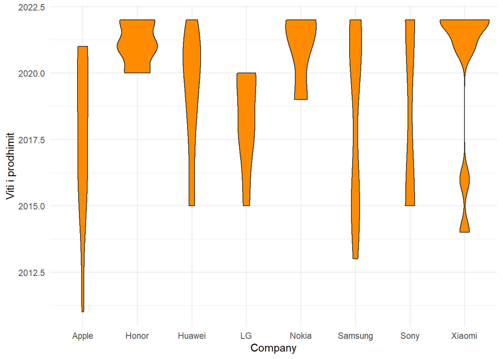

```r
smart %>%
 filter(!(GPU %in% c("PowerVR \r\n", "Mali\r\n", "Adreno \r\n", "IMG\r\n", "Adreno\r\n"))) %>%
 ggplot() +
  aes(x = Company, y = `Viti i prodhimit`) +
  geom_violin(adjust = 1L, scale = "area", fill = "#FF8C00") +
  theme_minimal()
```

```r
#testi hi katror qe tregon nese dy ndryshore cilesore jane te varura apo jo

library("MASS")

# .krijojme dataframin nga dataseti
car.data <- data.frame(smart$GPU,smart$CPU)

# krijojme tabelen
smart.data = table(smart$GPU,smart$CPU)
print(smart.data)
```

```
##
##                Apple A10 Fusion Apple A11 Bionic Apple A12 Bionic
##   Adrene                      0                0                0
##   Adreno                      0                0                0
##   Adreno \r\n                 0                0                0
##   Adreno\r\n                  0                0                0
##   Apple GPU                   0                1                2
##   ARM Mali                    0                0                0
##   IMG                         0                0                0
##   IMG\r\n                     0                0                0
##   Mali                        0                0                0
##   Mali\r\n                    0                0                0
##   PowerVR                     1                0                0
##   PowerVR \r\n                0                0                0
##
##                Apple A13 Bionic Apple A14 Bionic Apple A15 Bionic Apple A5
##   Adrene                      0                0                0        0
##   Adreno                      0                0                0        0
##   Adreno \r\n                 0                0                0        0
##   Adreno\r\n                  0                0                0        0
##   Apple GPU                   2                1                3        0
##   ARM Mali                    0                0                0        0
##   IMG                         0                0                0        0
##   IMG\r\n                     0                0                0        0
##   Mali                        0                0                0        0
##   Mali\r\n                    0                0                0        0
##   PowerVR                     0                0                0        1
##   PowerVR \r\n                0                0                0        0
##
##                Apple A8 Apple A9 Apple M1 ARM 11 ARM Cortex Exynos Kirin
##   Adrene              0        0        0      0          0      0     0
##   Adreno              0        0        0      0          0      0     0
##   Adreno \r\n         0        0        0      0          0      0     0
##   Adreno\r\n          0        0        0      0          0      0     0
##   Apple GPU           0        0        1      0          0      0     0
##   ARM Mali            0        0        0      0          1      0     0
##   IMG                 0        0        0      0          0      0     0
##   IMG\r\n             0        0        0      0          0      0     0
##   Mali                0        0        0      0          0      4     9
##   Mali\r\n            0        0        0      0          0      0     3
##   PowerVR             1        1        0      0          0      0     0
##   PowerVR \r\n        0        0        0      1          0      0     0
##
##                Leadcore Mediatek MediaTek Qualcomm Qualcomm   Unisoc
##   Adrene              0        0        0        1          0      0
##   Adreno              0        2        0       40          1      0
##   Adreno \r\n         0        0        0       14          1      0
##   Adreno\r\n          0        0        0        3          0      0
##   Apple GPU           0        0        0        0          0      0
##   ARM Mali            0        0        0        0          0      0
##   IMG                 0        0        0        0          0      4
##   IMG\r\n             0        0        0        0          0      2
##   Mali                0        5       11        1          0      0
##   Mali\r\n            1        3        2        0          0      2
##   PowerVR             0        6        1        0          0      0
##   PowerVR \r\n        0        5        2        0          0      0
```

```r
#funksioni per hi-katrorin
print(chisq.test(smart.data))
```

```
##
##  Pearson's Chi-squared test
##
## data:  smart.data
## X-squared = 620.84, df = 209, p-value < 2.2e-16
```

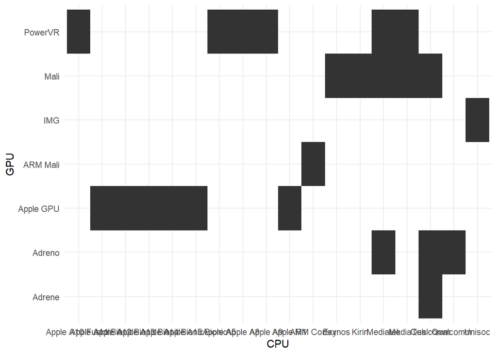

```r
smart %>%
 filter(!(GPU %in% c("PowerVR \r\n", "Mali\r\n", "Adreno \r\n", "IMG\r\n", "Adreno\r\n"))) %>%
 ggplot() +
  aes(x = CPU, y = GPU) +
  geom_tile(size = 1.2) +
  theme_minimal()
```

```r
x <- c(smart$Cmimi)
y <- c(smart$Shitjet)

# Aplikojme funksionin linear.
relation <- lm(y~x)

print(relation)
```

```
##
## Call:
## lm(formula = y ~ x)
##
## Coefficients:
## (Intercept)            x
##    14647271        -1229
```

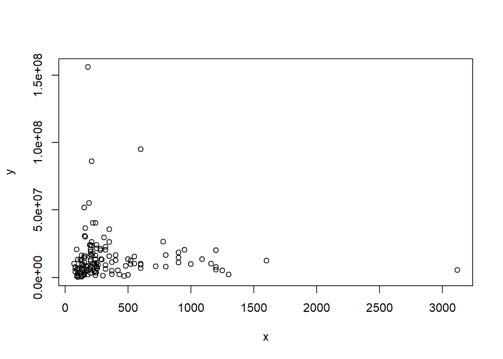

```r
#reja e pikave
x <- c(smart$Cmimi)
y <- c(smart$Shitjet)

plot(x,y)
```

```r
x <- c(smart$Cmimi)

# The resposne vector.
y <- c(smart$Shitjet)

# Apply the lm() function.
relation <- lm(y~x)

# parashikojme sa shitje do te kete nqs kemi nje cmim te caktuar
a <- data.frame(x =1500)
result <-  predict(relation,a)
print(result)
```

```
##        1
## 12803823
```

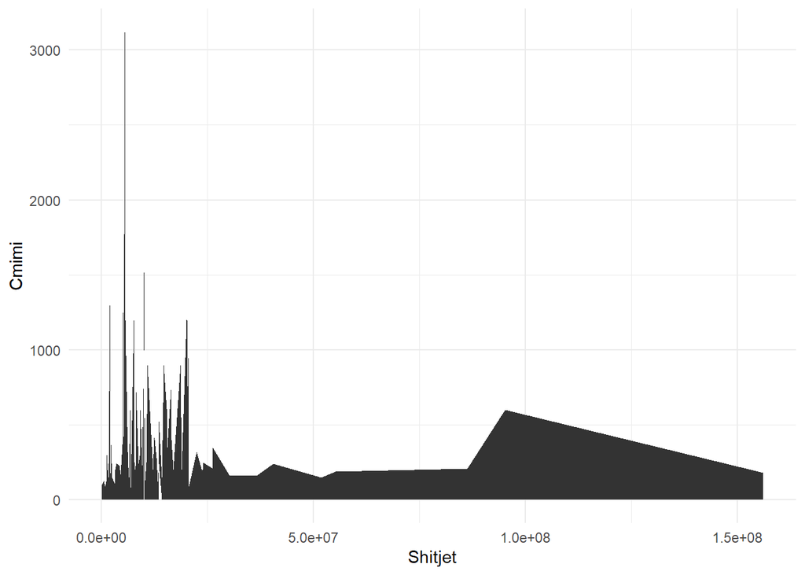

```r
smart %>%
 filter(!(GPU %in% c("PowerVR \r\n", "Mali\r\n", "Adreno \r\n", "IMG\r\n", "Adreno\r\n"))) %>%
 ggplot() +
  aes(x = Shitjet, y = Cmimi) +
  geom_area(size = 1.5) +
  theme_minimal()
```

#regresi linear cmimin dhe ROM

```r
x <- c(smart$Cmimi)
y <- c(smart$ROM)

#funksioni
relation <- lm(y~x)

print(relation)
```

```
##
## Call:
## lm(formula = y ~ x)
##
## Coefficients:
## (Intercept)            x
##      83.761        0.144
```

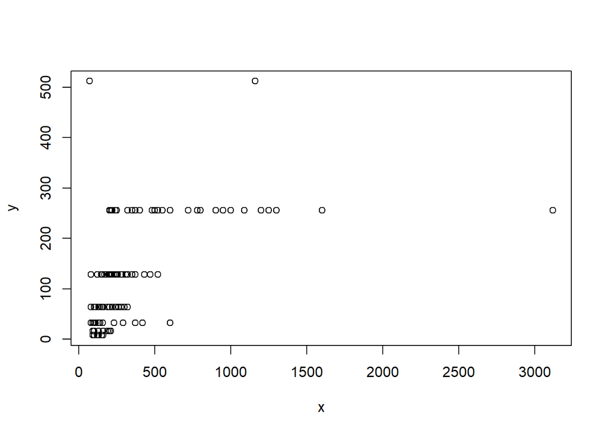

```r
#reja e pikave
plot(x,y)
```

```r
x <- c(smart$Cmimi)

y <- c(smart$ROM)

# Apply the lm() function.
relation <- lm(y~x)

# parashikojme sa ROM do te kete nqs kemi nje cmim te caktuar
a <- data.frame(x = 300)
result <-  predict(relation,a)
print(result)
```

```
##        1
## 126.9568
```

```r
x <- c(smart$ROM)
y <- c(smart$RAM)

#funksioni
relation <- lm(y~x)

print(relation)
```

```
##
## Call:
## lm(formula = y ~ x)
##
## Coefficients:
## (Intercept)            x
##     2.48056      0.02181
```

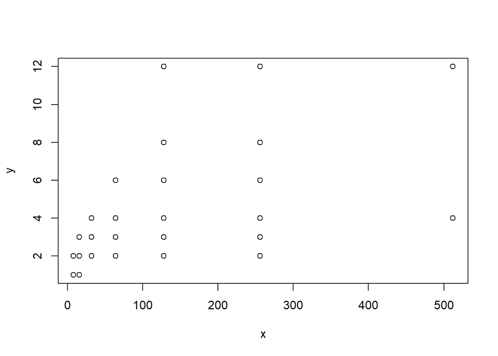

```r
plot(x,y)
```

```r
x <- c(smart$ROM)

y <- c(smart$RAM)

# Apply the lm() function.
relation <- lm(y~x)

# parashikojme sa ROM do te kete nqs kemi nje cmim te caktuar
a <- data.frame(x =100)
result <-  predict(relation,a)
print(result)
```

```
##        1
## 4.661063
```

```r
x <- c(smart$Cmimi)
y <- c(smart$RAM)

#funksioni
relation <- lm(y~x)

print(relation)
```

```
##
## Call:
## lm(formula = y ~ x)
##
## Coefficients:
## (Intercept)            x
##    4.034138     0.003892
```

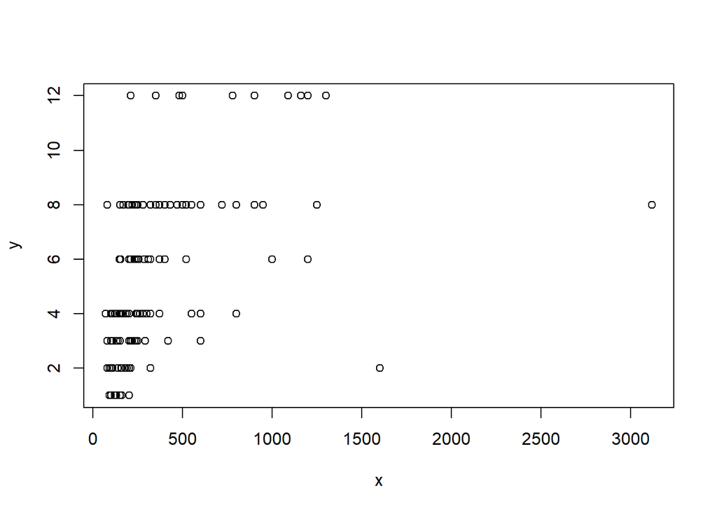

```r
plot(x,y)
```

```r
x <- c(smart$Cmimi)

y <- c(smart$RAM)

# Apply the lm() function.
relation <- lm(y~x)

# parashikojme sa RAM do te kete nqs kemi nje cmim te caktuar
a <- data.frame(x = 300)
result <-  predict(relation,a)
print(result)
```

```
##        1
## 5.201627
```

```r
x <- c(smart$Cmimi)
y <- c(smart$Cores)

#funksioni
relation <- lm(y~x)

print(relation)
```

```
##
## Call:
## lm(formula = y ~ x)
##
## Coefficients:
## (Intercept)            x
##    6.091156     0.001355
```

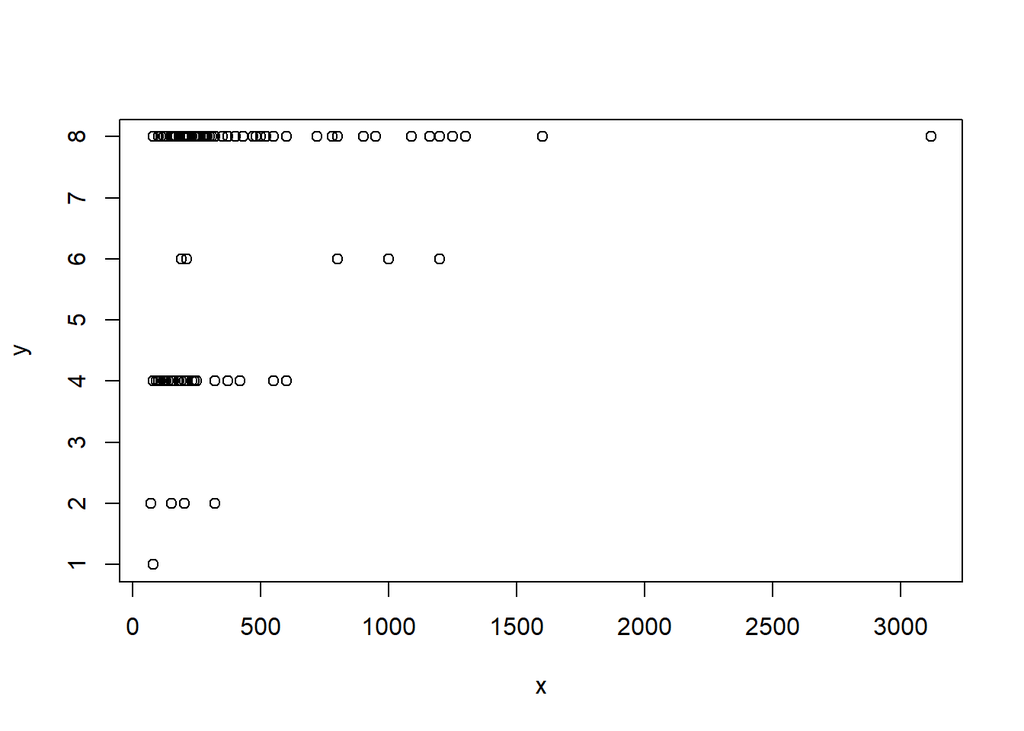

```r
plot(x,y)
```

```r
x <- c(smart$Cmimi)

y <- c(smart$Cores)

# Apply the lm() function.
relation <- lm(y~x)

# parashikojme sa cores do te kete nqs kemi nje cmim te caktuar
a <- data.frame(x = 300)
result <-  predict(relation,a)
print(result)
```

```
##        1
## 6.497636
```

```r
x <- c(smart$RAM)
y <- c(smart$Cores)

#funksioni
relation <- lm(y~x)

print(relation)
```

```
##
## Call:
## lm(formula = y ~ x)
##
## Coefficients:
## (Intercept)            x
##      4.5922       0.3655
```

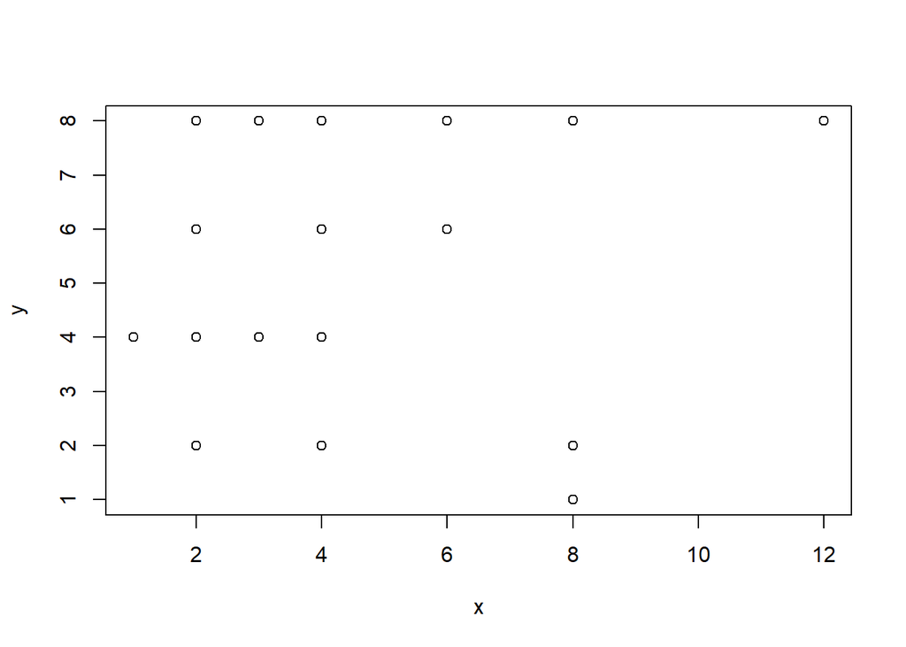

```r
plot(x,y)
```

```r
x <- c(smart$RAM)

y <- c(smart$Cores)

# Apply the lm() function.
relation <- lm(y~x)

# parashikojme sa RAM do te kete nqs kemi nje cmim te caktuar
a <- data.frame(x =8)
result <-  predict(relation,a)
print(result)
```

```
##        1
## 7.516222
```

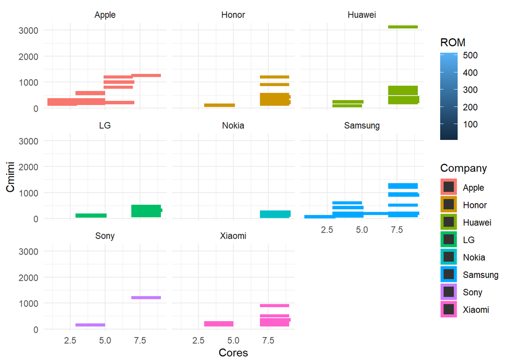

```r
#grafik
smart %>%
 filter(!(GPU %in% c("PowerVR \r\n", "Mali\r\n", "Adreno \r\n", "IMG\r\n", "Adreno\r\n"))) %>%
 ggplot() +
  aes(x = Cores, y = Cmimi, fill = ROM, colour = Company) +
  geom_tile(size = 1.5) +
  scale_fill_gradient() +
  scale_color_hue(direction = 1) +
  theme_minimal() +
  facet_wrap(vars(Company))
```

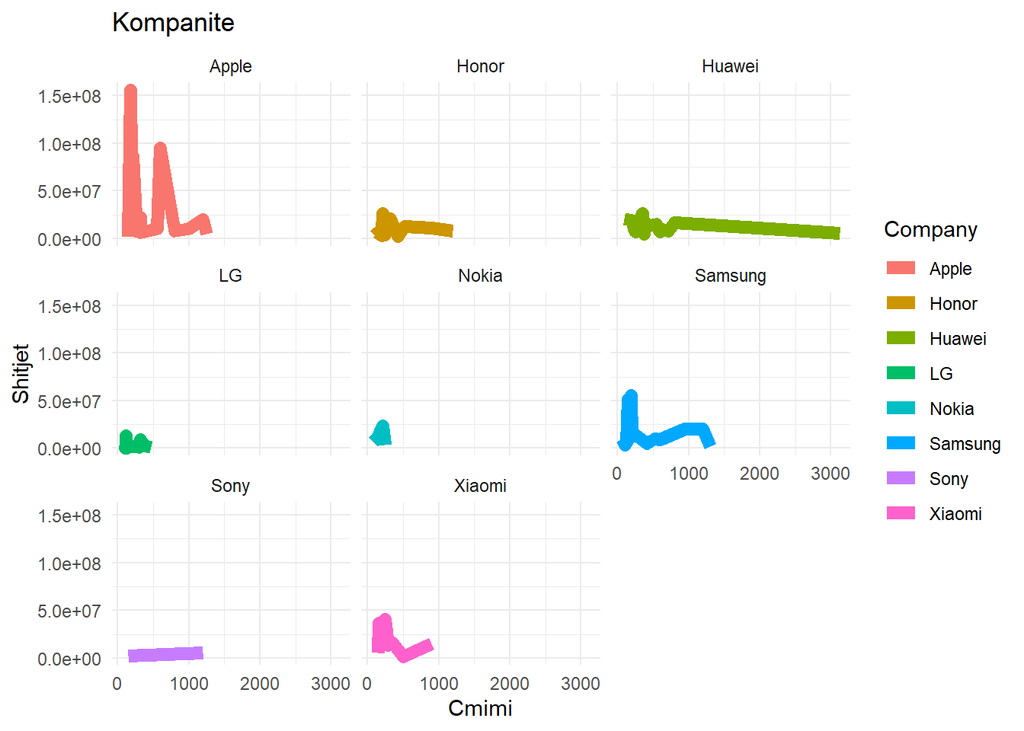

```r
smart %>%
 filter(!(GPU %in% c("PowerVR \r\n", "Mali\r\n", "Adreno \r\n", "IMG\r\n", "Adreno\r\n"))) %>%
 ggplot() +
  aes(
    x = Cmimi,
    y = Shitjet,
    fill = `Viti i prodhimit`,
    colour = Company
  ) +
  geom_line(size = 3.05) +
  scale_fill_gradient() +
  scale_color_hue(direction = 1) +
  labs(title = "Kompanite") +
  theme_minimal() +
  facet_wrap(vars(Company))
```